# Team

#loading in the dataset

```r
choco <- read.csv("https://raw.githubusercontent.com/xdaiISU/ds202materials/master/hwlabs/data/choco.csv")
str(choco)
```

```
## 'data.frame':    2312 obs. of  13 variables:
##  $ REF                 : int  2454 2458 2454 797 797 1015 1019 1011 1019 1011 ...
##  $ Company             : chr  "5150" "5150" "5150" "A. Morin" ...
##  $ Location            : chr  "U.S.A." "U.S.A." "U.S.A." "France" ...
##  $ Date                : int  2019 2019 2019 2012 2012 2013 2013 2013 2013 2013 ...
##  $ Bean_Origin         : chr  "Madagascar" "Dominican Republic" "Tanzania" "Peru" ...
##  $ Specific_Bean_Origin: chr  "Bejofo Estate, batch 1" "Zorzal, batch 1" "Kokoa Kamili, batch 1" "Peru" ...
##  $ Cocoa_Percent       : num  76 76 76 63 70 70 63 70 70 70 ...
##  $ Ingredients         : chr  "3- B,S,C" "3- B,S,C" "3- B,S,C" "4- B,S,C,L" ...
##  $ Characteristics1    : chr  "cocoa" "cocoa" "rich cocoa" "fruity" ...
##  $ Characteristics2    : chr  "blackberry" "vegetal" "fatty" "melon" ...
##  $ Characteristics3    : chr  "full body" "savory" "bready" "roasty" ...
##  $ Characteristics4    : chr  NA NA NA NA ...
##  $ Rating              : num  3.75 3.5 3.25 3.75 3.5 4 4 3.75 3.5 3.25 ...
```

#Problem 1

```r
class(choco)
```

```
## [1] "data.frame"
```

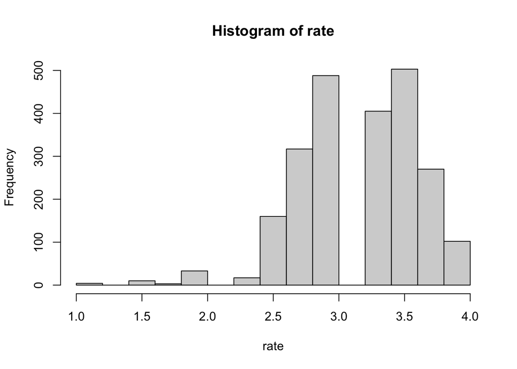

```r
rate <- choco$Rating
hist(rate)
```

# From the above, we can see that there are some outliers between 1-2 and there are no ratings which are above 5 either

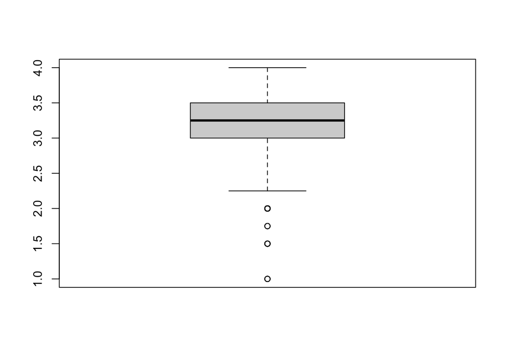

```r
boxplot(rate)
```

# From the boxplot, we are able to draw the same conclusions as the histrogram. We can see that there are 4 outlier points and there are no ratings above 5 in the scale

#Problem 2

```r
unique(choco$Location)
```

```
##  [1] "U.S.A."                "France"                "Fiji"
##  [4] "Vanuatu"               "Ecuador"               "Mexico"
##  [7] "Switzerland"           "Netherlands"           "Spain"
## [10] "Russia"                "Peru"                  "Canada"
## [13] "Italy"                 "Brazil"                "Nicaragua"
## [16] "U.K."                  "Australia"             "Philippines"
## [19] "Wales"                 "Belgium"               "Vietnam"
## [22] "Germany"               "Singapore"             "Venezuela"
## [25] "Malaysia"              "South Korea"           "Taiwan"
## [28] "Puerto Rico"           "Colombia"              "Japan"
## [31] "New Zealand"           "Costa Rica"            "Hungary"
## [34] "Amsterdam"             "Scotland"              "Martinique"
## [37] "Sao Tome"              "St. Lucia"             "Argentina"
## [40] "Guatemala"             "South Africa"          "Dominican Republic"
## [43] "Sao Tome & Principe"   "Bolivia"               "Portugal"
## [46] "Norway"                "Denmark"               "Grenada"
## [49] "Israel"                "India"                 "St.Vincent-Grenadines"
## [52] "Czech Republic"        "Thailand"              "Finland"
## [55] "Madagascar"            "Sweden"                "Poland"
## [58] "Austria"               "Honduras"              "U.A.E."
## [61] "Lithuania"             "Ireland"               "Chile"
## [64] "Ghana"                 "Iceland"               "Suriname"
## [67] "El Salvador"
```

```r
numRate <- table(choco$Location)
numRate2 <- sort(numRate, decreasing = TRUE)
numRate2
```

```
##
##                U.S.A.                France                Canada
##                   966                   175                   161
##                  U.K.                 Italy               Belgium
##                   126                    73                    59
##               Ecuador             Australia           Switzerland
##                    57                    53                    43
##               Germany                 Spain               Denmark
##                    42                    36                    31
##                 Japan             Venezuela               Austria
##                    31                    31                    30
##           New Zealand              Colombia               Hungary
##                    27                    25                    25
##                Brazil                  Peru            Madagascar
##                    24                    22                    17
##               Vietnam             Singapore             Amsterdam
##                    15                    13                    12
##    Dominican Republic           South Korea             Guatemala
##                    11                    11                    10
##             Nicaragua              Scotland                Taiwan
##                    10                    10                    10
##             Argentina            Costa Rica                Israel
##                     9                     9                     9
##             Lithuania                Mexico           Netherlands
##                     8                     8                     8
##                Poland              Honduras                Sweden
##                     8                     6                     6
##               Ireland           Philippines              Thailand
##                     5                     5                     5
##                U.A.E.                  Fiji               Iceland
##                     5                     4                     4
##           Puerto Rico              Sao Tome   Sao Tome & Principe
##                     4                     4                     4
##          South Africa               Vanuatu        Czech Republic
##                     4                     4                     3
##           El Salvador               Grenada              Malaysia
##                     3                     3                     3
##                Norway              Portugal                Russia
##                     3                     3                     3
##             St. Lucia               Bolivia                 Chile
##                     3                     2                     2
##               Finland                 India                 Ghana
##                     2                     2                     1
##            Martinique St.Vincent-Grenadines              Suriname
##                     1                     1                     1
##                 Wales
##                     1
```

#Most ratings are from the USA by over 5 times the second most. The second largest bunch is from France, Canada and U.K.

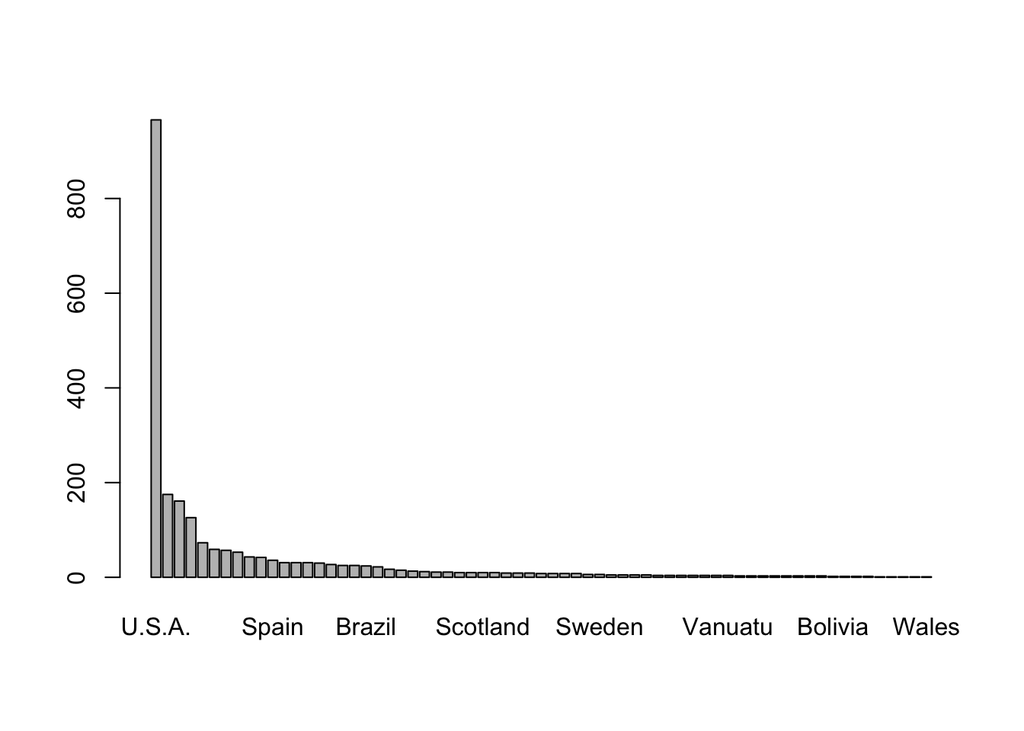

```r
barplot(numRate2)
```

#As we can see from the above graph, most of the ratings are from USA. There is a large difference between the first and second country with regards to the ratings. The countries which follow USA with ratings are France, Canada and UK

#Problem 3

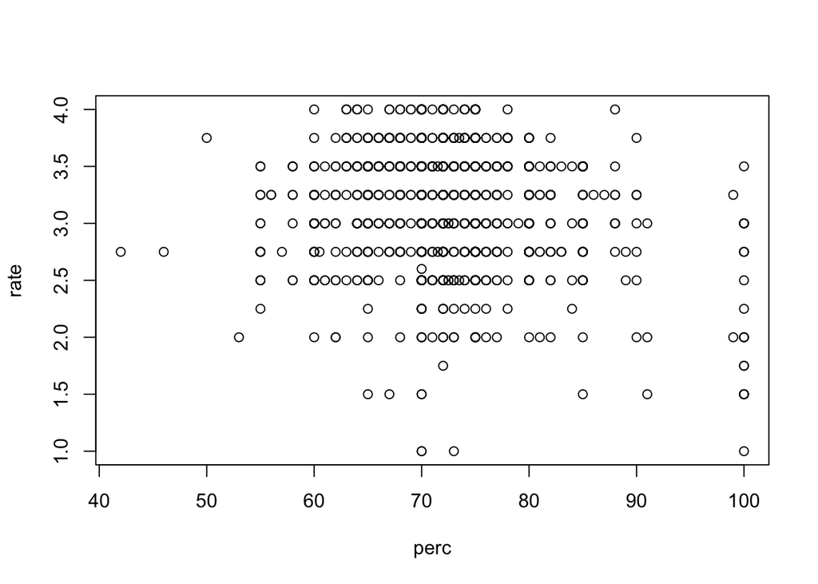

```r
perc <- choco$Cocoa_Percent
plot(perc,rate)
```

#Not that good, data all over the place

```r
cor(perc,rate)
```

```
## [1] -0.1510178
```

#Low correlation value

```r
summary(perc)
```

```
##    Min. 1st Qu.  Median    Mean 3rd Qu.    Max.
##   42.00   70.00   70.00   71.65   75.00  100.00
```

```r
summary(rate)
```

```
##    Min. 1st Qu.  Median    Mean 3rd Qu.    Max.
##   1.000   3.000   3.250   3.184   3.500   4.000
```

```r
best <- rate[rate == 4]
length(best)
```

```
## [1] 102
```

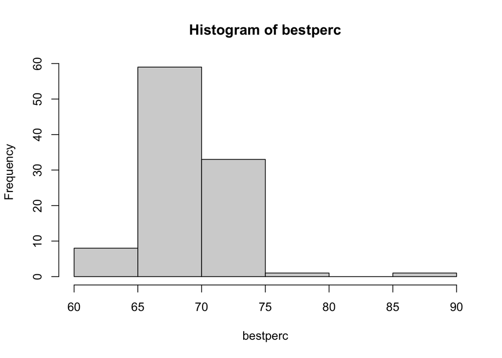

```r
choco1 <- order(choco$Rating, decreasing = TRUE)
fours <- choco1[1:102]
bestcho <- choco[fours,]
bestperc <- bestcho$Cocoa_Percent
hist(bestperc)
```

```r
summary(bestperc)
```

```
##    Min. 1st Qu.  Median    Mean 3rd Qu.    Max.
##   60.00   70.00   70.00   70.77   72.00   88.00
```

#The best chocolate has around 70 Cocoa Percent

#Problem 4

```r
unique(choco$Bean_Origin)
```

```
##  [1] "Madagascar"            "Dominican Republic"    "Tanzania"
##  [4] "Peru"                  "Bolivia"               "Venezuela"
##  [7] "Ecuador"               "Brazil"                "Papua New Guinea"
## [10] "Burma"                 "Panama"                "Colombia"
## [13] "Cuba"                  "Togo"                  "Sao Tome"
## [16] "Mexico"                "Fiji"                  "Vanuatu"
## [19] "Indonesia"             "Trinidad"              "Vietnam"
## [22] "Nicaragua"             "Ghana"                 "Belize"
## [25] "Blend"                 "Grenada"               "Jamaica"
## [28] "Guatemala"             "Costa Rica"            "Honduras"
## [31] "Haiti"                 "India"                 "Congo"
## [34] "Philippines"           "Solomon Islands"       "Uganda"
## [37] "Malaysia"              "Sri Lanka"             "Ivory Coast"
## [40] "Gabon"                 "Taiwan"                "Puerto Rico"
## [43] "Martinique"            "St. Lucia"             "Australia"
## [46] "Liberia"               "Sierra Leone"          "U.S.A."
## [49] "Nigeria"               "St.Vincent-Grenadines" "Thailand"
## [52] "Tobago"                "Bolvia"                "Sumatra"
## [55] "El Salvador"           "Cameroon"              "Samoa"
## [58] "Sao Tome & Principe"   "Principe"              "Sulawesi"
## [61] "Suriname"              "DR Congo"              "blend"
```

```r
origin <- choco$Bean_Origin
oritab <- table(choco$Bean_Origin)
most <- sort(oritab, decreasing = TRUE)
most
```

```
##
##             Venezuela                  Peru               Ecuador
##                   245                   220                   212
##    Dominican Republic            Madagascar                 Blend
##                   206                   163                   151
##             Nicaragua                Brazil               Bolivia
##                    92                    75                    72
##                Belize              Colombia              Tanzania
##                    67                    66                    64
##               Vietnam             Guatemala      Papua New Guinea
##                    64                    53                    49
##                Mexico            Costa Rica              Trinidad
##                    46                    43                    38
##                 Ghana                U.S.A.                 Haiti
##                    37                    30                    24
##              Honduras               Jamaica                 India
##                    23                    23                    21
##               Grenada           Philippines             Indonesia
##                    19                    19                    18
##                  Fiji              Sao Tome               Vanuatu
##                    15                    14                    13
##                  Cuba                 Congo                Uganda
##                    12                    11                    11
##       Solomon Islands             St. Lucia                Panama
##                    10                    10                     8
##              Malaysia           El Salvador           Puerto Rico
##                     7                     6                     6
##           Ivory Coast              Thailand             Australia
##                     5                     5                     3
##              Cameroon               Liberia               Nigeria
##                     3                     3                     3
##                 Samoa          Sierra Leone                  Togo
##                     3                     3                     3
##             Sri Lanka                Taiwan                Tobago
##                     2                     2                     2
##                 blend                Bolvia                 Burma
##                     1                     1                     1
##              DR Congo                 Gabon            Martinique
##                     1                     1                     1
##              Principe   Sao Tome & Principe St.Vincent-Grenadines
##                     1                     1                     1
##              Sulawesi               Sumatra              Suriname
##                     1                     1                     1
```

```r
Vene <- choco[origin == 'Venezuela', ]
unique(Vene$Characteristics1)
```

```
##   [1] "oily"                        "astringent"
##   [3] "nutty"                       "harsh"
##   [5] "alluring aroma"              "sandy"
##   [7] "sweet"                       "spicy"
##   [9] "waxy"                        "hot spice"
##  [11] "woody"                       "creamy"
##  [13] "vanilla"                     "very nutty"
##  [15] "mocha"                       "dark cocoa"
##  [17] "bitter then nutty rustic"    "smooth texture"
##  [19] "gritty"                      "fatty"
##  [21] "sweet grass"                 "intense"
##  [23] "over roasted"                "fruity"
##  [25] "bright fruit"                "assertive"
##  [27] "raspberry"                   "high astringent"
##  [29] "strong nutty with off notes" "mild metallic"
```

[output cut: 36 more lines]

```r
unique(Vene$Characteristics2)
```

```
##   [1] "nut"                  "nutty"                "mild choco"
##   [4] "leather"              "powdery"              "dirt"
##   [7] "moldy"                "strawberry"           "roasty"
##  [10] "red berry"            "fruit"                "nuts"
##  [13] "mild roasty"          "mild spice"           "very bitter"
##  [16] "intense"              "spicy pepper"         "macadamia"
##  [19] "light toffee"         "banana"               "earthy"
##  [22] "spicy"                "bland"                "mild bitter"
##  [25] "muted spice"          "fatty"                "coconut"
##  [28] "creamy"               "cooked banana"        "raisins"
##  [31] "slight hammy"         "bitter"               "dairy"
##  [34] "fruity"               "black licorice"       "chalky"
##  [37] "dirty"                "sandy"                "fudge-like"
##  [40] "ashey"                NA                     "burnt"
##  [43] "spice"                "floral"               "vegetal"
```

[output cut: 24 more lines]

```r
Peru <- choco[origin == 'Peru', ]
unique(Peru$Characteristics1)
```

```
##   [1] "fruity"                   "sweet"
##   [3] "cocoa"                    "green"
##   [5] "delicate"                 "grainy texture"
##   [7] "yellow fruit"             "intense"
##   [9] "hot cocoa"                "cardboard"
##  [11] "gritty"                   "dry"
##  [13] "sandy"                    "few grits"
##  [15] "raisins"                  "oily"
##  [17] "rich"                     "creamy"
##  [19] "floral"                   "dried fruit"
##  [21] "spicey"                   "black pepper"
##  [23] "molasses"                 "strong vanilla"
##  [25] "sticky"                   "flat"
##  [27] "roasty"                   "ripe grapes"
##  [29] "mild fruit"               "spicy"
```

[output cut: 38 more lines]

```r
unique(Peru$Characteristics2)
```

```
##   [1] "melon"                "cocoa"                "sour"
##   [4] "nutty"                "hazelnut"             "dairy"
##   [7] NA                     "rich"                 "dirt"
##  [10] "too sweet"            "sweet"                "blackcherry"
##  [13] "pungent"              "vegetal"              "vanilla"
##  [16] "raspberry"            "complex"              "fig"
##  [19] "mild metallic"        "cardamom"             "caramel"
##  [22] "rounded"              "off notes"            "moss"
##  [25] "bread"                "woody"                "subtle"
##  [28] "rich mocha"           "almost burnt"         "very acidic"
##  [31] "molasses"             "fruity"               "chocolatey"
##  [34] "floral"               "metallic"             "bitter"
##  [37] "odd"                  "coffee"               "floral notes"
##  [40] "orange"               "sandy"                "spice"
##  [43] "citrus"               "anise"                "buttery"
```

[output cut: 26 more lines]

```r
Vietnam <- choco[origin == 'Vietnam', ]
unique(Vietnam$Characteristics1)
```

```
##  [1] "nutty"          "sandy"          "cashew"         "earthy"
##  [5] "rich cocoa"     "unrefined"      "high acidity"   "gummy"
##  [9] "balanced"       "roasty"         "woody"          "green apple"
## [13] "raisins"        "muted"          "tropical berry" "intens"
## [17] "spicy"          "grit"           "mild bitter"    "intense"
## [21] "fatty"          "tart"           "molasses"       "sweet"
## [25] "sticky"         "creamy"         "gritty"         "citrus"
## [29] "cocoa"          "melon"          "long"           "cocounut"
## [33] "slight grainy"  "sour fig"       "swiss miss"     "fruit"
## [37] "smokey"         "vanilla"        "intense cocoa"
```

#I am using characteristics 1-4 to represent the flavors of the chooclate #There is a large variety of flavors from the two countries that produce chocolate, so it is safe to assume that a specific flavor does not come from a specific place # I also tested a random country in the middle and there was a large variety of flavors from there too

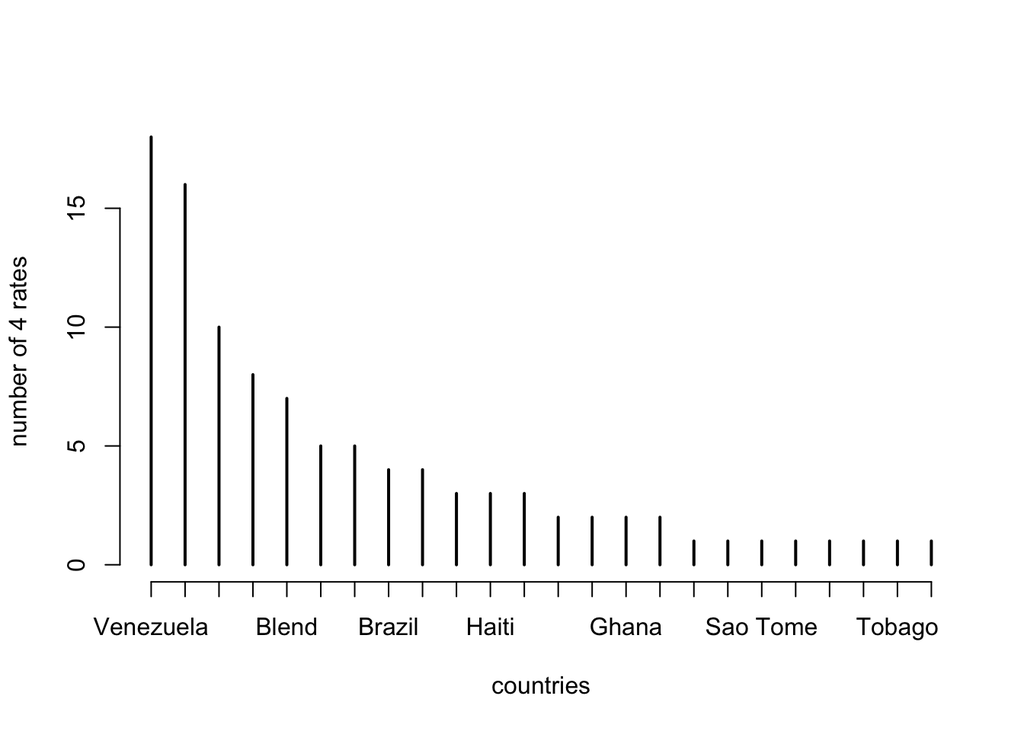

```r
bestori <- table(bestcho$Bean_Origin)
bestori1 <- sort(bestori, decreasing = TRUE)
plot(bestori1, xlab = 'countries', ylab = 'number of 4 rates')
```

#It does not look like there is a best origin as the highest ranking of chocolates come from multiple countries #The highest amounts were Venezuela and Peru, but they produced the most chocolate as well #Comparing it to the highest amount of origins, it loosely follows the countries that produce to most chocolate #Some countries that produce a lot did not produce any 4 rate chocolate (Dominican Republic), so origin does has some effect

#Problem 5 #(First Analysis - Rithwik Gokhale) #My analysis will be comparing the years of the chocolate manufacturing vs the % cacao in the chocolates being compared.

```r
years <- choco$Date
unique(sort(years, decreasing = TRUE))
```

```
##  [1] 2020 2019 2018 2017 2016 2015 2014 2013 2012 2011 2010 2009 2008 2007 2006
```

```r
cor(choco$Date, choco$Cocoa_Percent)
```

```
## [1] 0.02186544
```

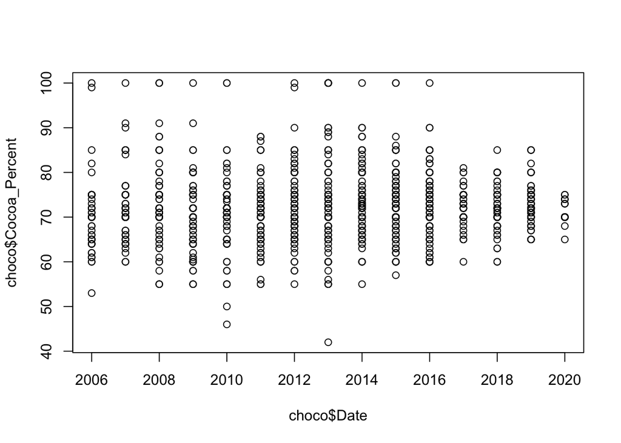

```r
plot(choco$Date, choco$Cocoa_Percent)
```

#(Second Analysis - Tyren Teav) #Our first analysis will be comparing years chocolate were produced and their ratings, we will compare the beginning and end of each decade. Years 2006, 2010, 2014, 2018. #We want to see if the year has any affect on the ratings. The other analysis will be the year vs. the cocoa percentage to see if there were changes to percent use over the years.

```r
year <- choco$Date
first <- choco[year == 2006,]

summary(first$Rating)
```

```
##    Min. 1st Qu.  Median    Mean 3rd Qu.    Max.
##   1.000   2.562   3.000   3.004   3.688   4.000
```

```r
second <- choco[year == 2010,]

summary(second$Rating)
```

```
##    Min. 1st Qu.  Median    Mean 3rd Qu.    Max.
##   1.500   2.750   3.250   3.152   3.500   4.000
```

```r
third <- choco[year == 2014,]

summary(third$Rating)
```

```
##    Min. 1st Qu.  Median    Mean 3rd Qu.    Max.
##   2.000   2.875   3.250   3.189   3.500   4.000
```

```r
fourth <- choco[year == 2018,]

summary(fourth$Rating)
```

```
##    Min. 1st Qu.  Median    Mean 3rd Qu.    Max.
##   2.000   3.000   3.250   3.192   3.500   4.000
```

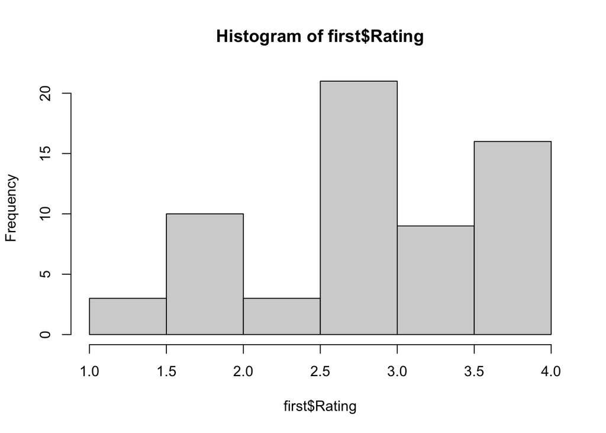

```r
#Looks like the lower rated chocolate got better over the years, possibly higher standards, newer equipment to improve chocolate, newer techniques to create chocolate.

hist(first$Rating)
```

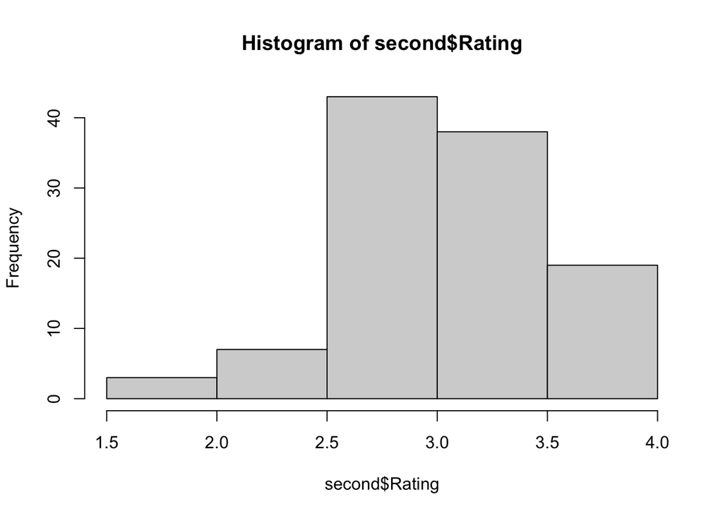

```r
hist(second$Rating)
```

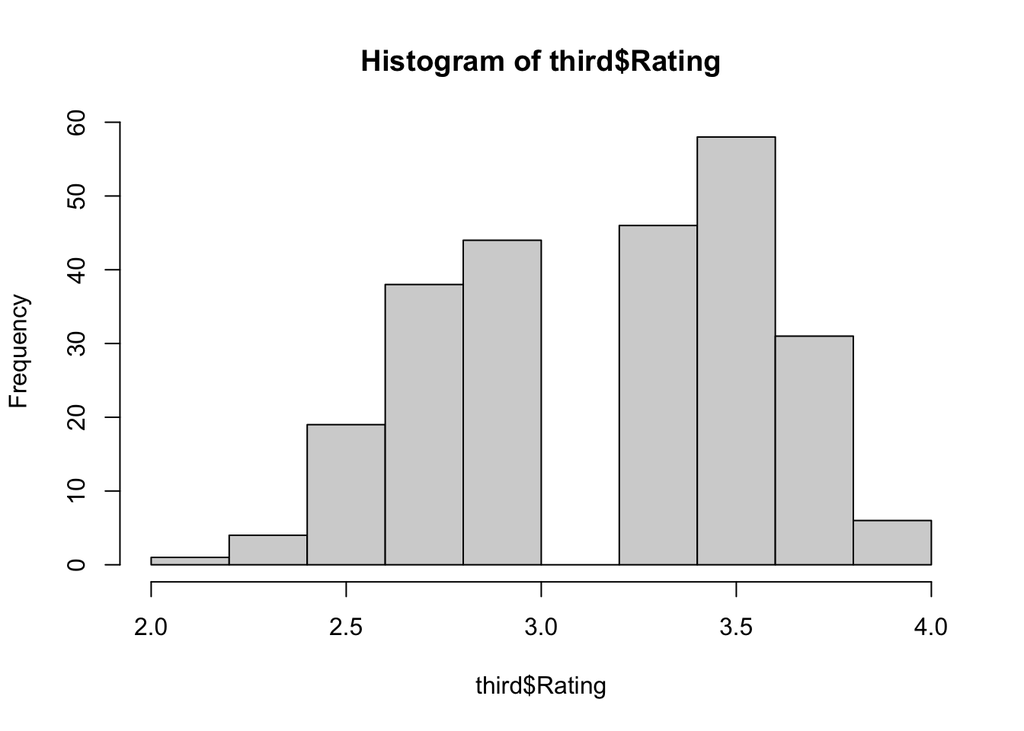

```r
hist(third$Rating)
```

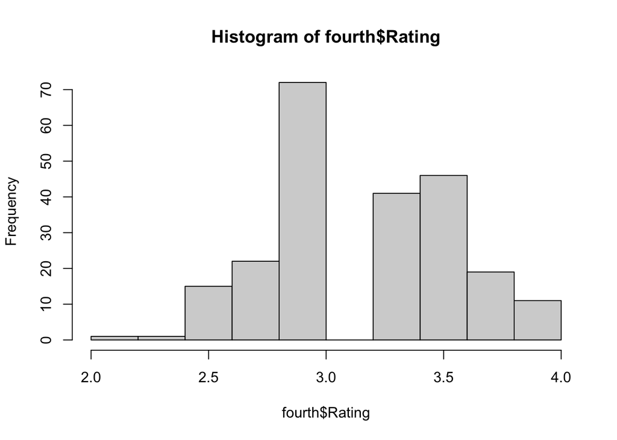

```r
hist(fourth$Rating)
```

```r
#Much more chocolate was produced over the years and as mentioned earlier the lower ratings increased, having no ratings of less than 2 for years 2014 and 2018
```